# Final Project

Aidan Kleinman

```r
library(rvest)
library(tidyverse)
library(genius)
library(dplyr)
library(DataComputing)
library(mosaic)
```

```r
# read webpage for Grammy Awards
webpage <- read_html("https://en.wikipedia.org/wiki/Grammy_Award_for_Record_of_the_Year")

# copy xpath for table of 1980s
XPATH80 <- '/html/body/div[3]/div[3]/div[5]/div[1]/table[5]'

# run the following to create table of songs from 1980s
table_1980 <-
  webpage %>%
  html_nodes(xpath = XPATH80) %>%
  html_table(fill = TRUE)

d1980 <- table_1980[[1]]
d1980 %>%
  mutate(across(.fns = ~gsub("\\[.*?\\]", "", .)))
```

| Year[I] | Record | Artist(s) | Production team |
| --- | --- | --- | --- |
| 1980 | NA | NA | NA |
| 1980 | "What a Fool Believes" | The Doobie Brothers | Ted Templeman, producer |
| 1980 | "After the Love Has Gone" | Earth, Wind & Fire | Maurice White, producer |
| 1980 | "I Will Survive" | Gloria Gaynor | Freddie Perren & Dino Fekaris, producers |
| 1980 | "The Gambler" | Kenny Rogers | Larry Butler, producer |
| 1980 | "You Don't Bring Me Flowers" | Barbra Streisand & Neil Diamond | Bob Gaudio, producer |
| 1981 | NA | NA | NA |
| 1981 | "Sailing" | Christopher Cross | Michael Omartian, producer |
| 1981 | "The Rose" | Bette Midler | Paul A. Rothchild, producer |
| 1981 | "Lady" | Kenny Rogers | Lionel Richie, producer |

[output cut: 50 more lines]

```r
# read webpage for Grammy Awards
webpage <- read_html("https://en.wikipedia.org/wiki/Grammy_Award_for_Record_of_the_Year")

# copy xpath for table of 1990s
XPATH90 <- '/html/body/div[3]/div[3]/div[5]/div[1]/table[6]'

# run the following to create table of songs from 1990s
table_1990 <-
  webpage %>%
  html_nodes(xpath = XPATH90) %>%
  html_table(fill = TRUE)

d1990 <- table_1990[[1]]
d1990 %>%
  mutate(across(.fns = ~gsub("\\[.*?\\]", "", .)))
```

| Year[I] | Record | Artist(s) | Production team |
| --- | --- | --- | --- |
| 1990 | NA | NA | NA |
| 1990 | "Wind Beneath My Wings" | Bette Midler | Arif Mardin, producer |
| 1990 | "The End of the Innocence" | Don Henley | Don Henley & Bruce Hornsby, producers |
| 1990 | "She Drives Me Crazy" | Fine Young Cannibals | David Z & Fine Young Cannibals, producers |
| 1990 | "We Didn't Start the Fire" | Billy Joel | Mick Jones & Billy Joel, producers |
| 1990 | "The Living Years" | Mike + The Mechanics | Christopher Neil & Mike Rutherford, producers |
| 1991 | NA | NA | NA |
| 1991 | "Another Day in Paradise" | Phil Collins | Hugh Padgham & Phil Collins, producers |
| 1991 | "Vision of Love" | Mariah Carey | Rhett Lawrence & Narada Michael Walden, producers |
| 1991 | "U Can't Touch This" | MC Hammer | MC Hammer, producer |

[output cut: 50 more lines]

```r
# read webpage for Grammy Awards
webpage <- read_html("https://en.wikipedia.org/wiki/Grammy_Award_for_Record_of_the_Year")

# copy xpath for table of 2000s
XPATH00 <- '/html/body/div[3]/div[3]/div[5]/div[1]/table[7]'

# run the following to create table of songs from 2000s
table_2000 <-
  webpage %>%
  html_nodes(xpath = XPATH00) %>%
  html_table(fill = TRUE)

d2000 <- table_2000[[1]]
d2000 %>%
  mutate(across(.fns = ~ gsub("\\[.*?\\]", "", .)))
```

| Year[I] | Record | Artist(s) | Production team |
| --- | --- | --- | --- |
| 2000 | NA | NA | NA |
| 2000 | "Smooth" | Santana featuring Rob Thomas | Matt Serletic, producer; David Thoener, engineer/mixer |
| 2000 | "Believe" | Cher | Brian Rawling & Mark Taylor, producers; Mark Taylor, engineer/mixer |
| 2000 | "I Want It That Way" | Backstreet Boys | Kristian Lundin & Max Martin, producers; Kristian Lundin & Max Martin, engineers/mixers |
| 2000 | "Livin' la Vida Loca" | Ricky Martin | Desmond Child & Robi Rosa, producers; Charles Dye, engineer/mixer |
| 2000 | "No Scrubs" | TLC | Kevin "Shekspere" Briggs, producer; Leslie Brathwaite & Carlton Lynn, engineers/mixers |
| 2001 | NA | NA | NA |
| 2001 | "Beautiful Day" | U2 | Brian Eno & Daniel Lanois, producers; Steve Lillywhite & Richard Rainey, engineer/mixers |
| 2001 | "Bye Bye Bye" | *NSYNC | Jake Lundin & Kristian Lundin, producers; Mike Tucker, engineer/mixer |
| 2001 | "I Try" | Macy Gray | Andrew Slater, producer; Darryl Swann & Dave Way, engineers/mixers |

[output cut: 50 more lines]

```r
# read webpage for Grammy Awards
webpage <- read_html("https://en.wikipedia.org/wiki/Grammy_Award_for_Record_of_the_Year")

# copy xpath for table of 2010s
XPATH10 <- '/html/body/div[3]/div[3]/div[5]/div[1]/table[8]'

# run the following to create table of songs from 2010s
table_2010 <-
  webpage %>%
  html_nodes(xpath = XPATH10) %>%
  html_table(fill = TRUE)

d2010 <- table_2010[[1]]
d2010 %>%
  mutate(across(.fns = ~ gsub("\\[.*?\\]", "", .)))
```

| Year[I] | Record | Artist(s) | Production team |
| --- | --- | --- | --- |
| 2010 | NA | NA | NA |
| 2010 | "Use Somebody" | Kings of Leon | Jacquire King & Angelo Petraglia, producers; Jacquire King, engineer/mixer |
| 2010 | "Halo" | Beyoncé | Beyoncé Knowles & Ryan Tedder, producers; Jim Caruana, Mark "Spike" Stent & Ryan Tedder, engineers/mixers |
| 2010 | "I Gotta Feeling" | The Black Eyed Peas | David Guetta & Frederick Riesterer, producers; will.i.am, Dylan "3-D" Dresdow & Padraic "Padlock" Kerin, engineers/mixers |
| 2010 | "Poker Face" | Lady Gaga | RedOne, producer; Robert Orton, RedOne & Dave Russell, engineers/mixers |
| 2010 | "You Belong with Me" | Taylor Swift | Nathan Chapman & Taylor Swift, producers; Chad Carlson & Justin Niebank, engineers/mixers |
| 2011 | NA | NA | NA |
| 2011 | "Need You Now" | Lady Antebellum | Lady Antebellum & Paul Worley, producers; Clarke Schleicher, engineer/mixer |
| 2011 | "Empire State of Mind" | Jay Z featuring Alicia Keys | Angela Hunte, Jane't "Jnay" Sewell-Ulepic & Al Shux, producers; Ken Duro Ifill, Gimel "Young Guru" Keaton & Ann Mincieli, engineers/mixers |
| 2011 | "F*** You" | CeeLo Green | The Smeezingtons, producers |

[output cut: 54 more lines]

```r
ROY1980s <- d1980 %>%
  rename(track = Record) %>%
  rename(artist = `Artist(s)`) %>%
  rename(year = `Year[I]`) %>%
  na.omit() %>%
  mutate(across(.fns = ~ gsub("\\[.*?\\]", "", .)))
head(ROY1980s)
```

|  | year | track | artist | Production team |
| --- | --- | --- | --- | --- |
| 1 | 1980 | "What a Fool Believes" | The Doobie Brothers | Ted Templeman, producer |
| 2 | 1980 | "After the Love Has Gone" | Earth, Wind & Fire | Maurice White, producer |
| 3 | 1980 | "I Will Survive" | Gloria Gaynor | Freddie Perren & Dino Fekaris, producers |
| 4 | 1980 | "The Gambler" | Kenny Rogers | Larry Butler, producer |
| 5 | 1980 | "You Don't Bring Me Flowers" | Barbra Streisand & Neil Diamond | Bob Gaudio, producer |
| 6 | 1981 | "Sailing" | Christopher Cross | Michael Omartian, producer |

```r
ROY1990s <- d1990 %>%
  rename(track = Record) %>%
  rename(artist = `Artist(s)`) %>%
  rename(year = `Year[I]`) %>%
  na.omit() %>%
  mutate(across(.fns = ~ gsub("\\[.*?\\]", "", .)))
head(ROY1990s)
```

|  | year | track | artist | Production team |
| --- | --- | --- | --- | --- |
| 1 | 1990 | "Wind Beneath My Wings" | Bette Midler | Arif Mardin, producer |
| 2 | 1990 | "The End of the Innocence" | Don Henley | Don Henley & Bruce Hornsby, producers |
| 3 | 1990 | "She Drives Me Crazy" | Fine Young Cannibals | David Z & Fine Young Cannibals, producers |
| 4 | 1990 | "We Didn't Start the Fire" | Billy Joel | Mick Jones & Billy Joel, producers |
| 5 | 1990 | "The Living Years" | Mike + The Mechanics | Christopher Neil & Mike Rutherford, producers |
| 6 | 1991 | "Another Day in Paradise" | Phil Collins | Hugh Padgham & Phil Collins, producers |

```r
ROY2000s <- d2000 %>%
  rename(track = Record) %>%
  rename(artist = `Artist(s)`) %>%
  rename(year = `Year[I]`) %>%
  na.omit() %>%
  mutate(across(.fns = ~ gsub("\\[.*?\\]", "", .)))
head(ROY2000s)
```

|  | year | track | artist | Production team |
| --- | --- | --- | --- | --- |
| 1 | 2000 | "Smooth" | Santana featuring Rob Thomas | Matt Serletic, producer; David Thoener, engineer/mixer |
| 2 | 2000 | "Believe" | Cher | Brian Rawling & Mark Taylor, producers; Mark Taylor, engineer/mixer |
| 3 | 2000 | "I Want It That Way" | Backstreet Boys | Kristian Lundin & Max Martin, producers; Kristian Lundin & Max Martin, engineers/mixers |
| 4 | 2000 | "Livin' la Vida Loca" | Ricky Martin | Desmond Child & Robi Rosa, producers; Charles Dye, engineer/mixer |
| 5 | 2000 | "No Scrubs" | TLC | Kevin "Shekspere" Briggs, producer; Leslie Brathwaite & Carlton Lynn, engineers/mixers |
| 6 | 2001 | "Beautiful Day" | U2 | Brian Eno & Daniel Lanois, producers; Steve Lillywhite & Richard Rainey, engineer/mixers |

```r
ROY2010s <- d2010 %>%
  rename(track = Record) %>%
  rename(artist = `Artist(s)`) %>%
  rename(year = `Year[I]`) %>%
  na.omit() %>%
  mutate(across(.fns = ~ gsub("\\[.*?\\]", "", .)))
head(ROY2010s)
```

|  | year | track | artist | Production team |
| --- | --- | --- | --- | --- |
| 1 | 2010 | "Use Somebody" | Kings of Leon | Jacquire King & Angelo Petraglia, producers; Jacquire King, engineer/mixer |
| 2 | 2010 | "Halo" | Beyoncé | Beyoncé Knowles & Ryan Tedder, producers; Jim Caruana, Mark "Spike" Stent & Ryan Tedder, engineers/mixers |
| 3 | 2010 | "I Gotta Feeling" | The Black Eyed Peas | David Guetta & Frederick Riesterer, producers; will.i.am, Dylan "3-D" Dresdow & Padraic "Padlock" Kerin, engineers/mixers |
| 4 | 2010 | "Poker Face" | Lady Gaga | RedOne, producer; Robert Orton, RedOne & Dave Russell, engineers/mixers |
| 5 | 2010 | "You Belong with Me" | Taylor Swift | Nathan Chapman & Taylor Swift, producers; Chad Carlson & Justin Niebank, engineers/mixers |
| 6 | 2011 | "Need You Now" | Lady Antebellum | Lady Antebellum & Paul Worley, producers; Clarke Schleicher, engineer/mixer |

```r
# get lyrics for songs 1980s
lyrics80s <- ROY1980s %>%
  add_genius(artist, track, type = "lyrics")
head(lyrics80s)
```

| year | track | artist | Production team | track_title | line | lyric |
| --- | --- | --- | --- | --- | --- | --- |
| 1980 | "What a Fool Believes" | The Doobie Brothers | Ted Templeman, producer | What a Fool Believes | 1 | He came from somewhere back in her long ago |
| 1980 | "What a Fool Believes" | The Doobie Brothers | Ted Templeman, producer | What a Fool Believes | 2 | The sentimental fool don't see |
| 1980 | "What a Fool Believes" | The Doobie Brothers | Ted Templeman, producer | What a Fool Believes | 3 | Tryin' hard to recreate |
| 1980 | "What a Fool Believes" | The Doobie Brothers | Ted Templeman, producer | What a Fool Believes | 4 | What had yet to be created once in her life |
| 1980 | "What a Fool Believes" | The Doobie Brothers | Ted Templeman, producer | What a Fool Believes | 5 | She musters a smile for his nostalgic tale |
| 1980 | "What a Fool Believes" | The Doobie Brothers | Ted Templeman, producer | What a Fool Believes | 6 | Never coming near what he wanted to say |

```r
# get lyrics for songs 1990s
lyrics90s <- ROY1990s %>%
  add_genius(artist, track, type = "lyrics")
head(lyrics90s)
```

| year | track | artist | Production team | track_title | line | lyric |
| --- | --- | --- | --- | --- | --- | --- |
| 1990 | "Wind Beneath My Wings" | Bette Midler | Arif Mardin, producer | Wind Beneath My Wings | 1 | Oh, oh, oh, oh |
| 1990 | "Wind Beneath My Wings" | Bette Midler | Arif Mardin, producer | Wind Beneath My Wings | 2 | It must have been cold there in my shadow |
| 1990 | "Wind Beneath My Wings" | Bette Midler | Arif Mardin, producer | Wind Beneath My Wings | 3 | To never have sunlight on your face |
| 1990 | "Wind Beneath My Wings" | Bette Midler | Arif Mardin, producer | Wind Beneath My Wings | 4 | You were content to let me shine, that's your way |
| 1990 | "Wind Beneath My Wings" | Bette Midler | Arif Mardin, producer | Wind Beneath My Wings | 5 | You always walked a step behind |
| 1990 | "Wind Beneath My Wings" | Bette Midler | Arif Mardin, producer | Wind Beneath My Wings | 6 | So I was the one with all the glory |

```r
# get lyrics for songs 2000s
lyrics00s <- ROY2000s %>%
  add_genius(artist, track, type = "lyrics")
head(lyrics00s)
```

| year | track | artist | Production team | track_title | line | lyric |
| --- | --- | --- | --- | --- | --- | --- |
| 2000 | "Believe" | Cher | Brian Rawling & Mark Taylor, producers; Mark Taylor, engineer/mixer | Believe | 1 | After love, after love |
| 2000 | "Believe" | Cher | Brian Rawling & Mark Taylor, producers; Mark Taylor, engineer/mixer | Believe | 2 | After love, after love |
| 2000 | "Believe" | Cher | Brian Rawling & Mark Taylor, producers; Mark Taylor, engineer/mixer | Believe | 3 | After love, after love |
| 2000 | "Believe" | Cher | Brian Rawling & Mark Taylor, producers; Mark Taylor, engineer/mixer | Believe | 4 | After love, after love |
| 2000 | "Believe" | Cher | Brian Rawling & Mark Taylor, producers; Mark Taylor, engineer/mixer | Believe | 5 | After love, after love |
| 2000 | "Believe" | Cher | Brian Rawling & Mark Taylor, producers; Mark Taylor, engineer/mixer | Believe | 6 | No matter how hard I try |

```r
# get lyrics for songs 2010s
lyrics10s <- ROY2010s %>%
  add_genius(artist, track, type = "lyrics")
head(lyrics10s)
```

| year | track | artist | Production team | track_title | line | lyric |
| --- | --- | --- | --- | --- | --- | --- |
| 2010 | "Use Somebody" | Kings of Leon | Jacquire King & Angelo Petraglia, producers; Jacquire King, engineer/mixer | Use Somebody | 1 | I've been roamin' around, always lookin' down at all I see |
| 2010 | "Use Somebody" | Kings of Leon | Jacquire King & Angelo Petraglia, producers; Jacquire King, engineer/mixer | Use Somebody | 2 | Painted faces fill the places I can't reach |
| 2010 | "Use Somebody" | Kings of Leon | Jacquire King & Angelo Petraglia, producers; Jacquire King, engineer/mixer | Use Somebody | 3 | You know that I could use somebody |
| 2010 | "Use Somebody" | Kings of Leon | Jacquire King & Angelo Petraglia, producers; Jacquire King, engineer/mixer | Use Somebody | 4 | You know that I could use somebody |
| 2010 | "Use Somebody" | Kings of Leon | Jacquire King & Angelo Petraglia, producers; Jacquire King, engineer/mixer | Use Somebody | 5 | Someone like you and all you know and how you speak |
| 2010 | "Use Somebody" | Kings of Leon | Jacquire King & Angelo Petraglia, producers; Jacquire King, engineer/mixer | Use Somebody | 6 | Countless lovers under cover of the street |

```r
Lyrics80to90s <-
  lyrics80s %>%
  full_join(lyrics90s)
```

```r
Lyrics80sto00s <-
  Lyrics80to90s %>%
  full_join(lyrics00s)
```

```r
Lyrics80sto10s <-
  Lyrics80sto00s %>%
  full_join(lyrics10s) %>%
  select(year, track, artist, track_title, line, lyric)
```

```r
head(Lyrics80sto10s)
```

| year | track | artist | track_title | line | lyric |
| --- | --- | --- | --- | --- | --- |
| 1980 | "What a Fool Believes" | The Doobie Brothers | What a Fool Believes | 1 | He came from somewhere back in her long ago |
| 1980 | "What a Fool Believes" | The Doobie Brothers | What a Fool Believes | 2 | The sentimental fool don't see |
| 1980 | "What a Fool Believes" | The Doobie Brothers | What a Fool Believes | 3 | Tryin' hard to recreate |
| 1980 | "What a Fool Believes" | The Doobie Brothers | What a Fool Believes | 4 | What had yet to be created once in her life |
| 1980 | "What a Fool Believes" | The Doobie Brothers | What a Fool Believes | 5 | She musters a smile for his nostalgic tale |
| 1980 | "What a Fool Believes" | The Doobie Brothers | What a Fool Believes | 6 | Never coming near what he wanted to say |

```r
Decades <- Lyrics80sto10s %>%
  mutate(decade = ifelse(year %in% 1980:1989, 1980,

                  ifelse(year %in% 1990:1999, 1990,

                  ifelse(year %in% 2000:2009, 2000,

                  ifelse(year %in% 2010:2019, 2010, 0)))))
Decades
```

| year | track | artist | track_title | line | lyric | decade |
| --- | --- | --- | --- | --- | --- | --- |
| 1980 | "What a Fool Believes" | The Doobie Brothers | What a Fool Believes | 1 | He came from somewhere back in her long ago | 1980 |
| 1980 | "What a Fool Believes" | The Doobie Brothers | What a Fool Believes | 2 | The sentimental fool don't see | 1980 |
| 1980 | "What a Fool Believes" | The Doobie Brothers | What a Fool Believes | 3 | Tryin' hard to recreate | 1980 |
| 1980 | "What a Fool Believes" | The Doobie Brothers | What a Fool Believes | 4 | What had yet to be created once in her life | 1980 |
| 1980 | "What a Fool Believes" | The Doobie Brothers | What a Fool Believes | 5 | She musters a smile for his nostalgic tale | 1980 |
| 1980 | "What a Fool Believes" | The Doobie Brothers | What a Fool Believes | 6 | Never coming near what he wanted to say | 1980 |
| 1980 | "What a Fool Believes" | The Doobie Brothers | What a Fool Believes | 7 | Only to realize it never really was | 1980 |
| 1980 | "What a Fool Believes" | The Doobie Brothers | What a Fool Believes | 8 | She had a place in his life | 1980 |
| 1980 | "What a Fool Believes" | The Doobie Brothers | What a Fool Believes | 9 | He never made her think twice | 1980 |
| 1980 | "What a Fool Believes" | The Doobie Brothers | What a Fool Believes | 10 | As he rises to her apology | 1980 |

[output cut: 990 more lines]

```r
library(ngram)
library(qdap)
library(tidytext)
library(DataComputing)
```

### Extract stop_words

```r
stop_words <- c("ba", "du", "yeah", "da", "ya", "ooh", "gonna", "na", "uh", "la","hol")
WordsStop <- data.frame("word" = stop_words)

Words <- Decades %>%
  unnest_tokens(word, lyric)

Stopped <- Words %>%
  anti_join(WordsStop)
WordsStop
```

| word |
| --- |
| ba |
| du |
| yeah |
| da |
| ya |
| ooh |
| gonna |
| na |
| uh |
| la |

[output cut: 1 more lines]

```r
Stopped
```

| year | track | artist | track_title | line | decade | word |
| --- | --- | --- | --- | --- | --- | --- |
| 1980 | "What a Fool Believes" | The Doobie Brothers | What a Fool Believes | 1 | 1980 | he |
| 1980 | "What a Fool Believes" | The Doobie Brothers | What a Fool Believes | 1 | 1980 | came |
| 1980 | "What a Fool Believes" | The Doobie Brothers | What a Fool Believes | 1 | 1980 | from |
| 1980 | "What a Fool Believes" | The Doobie Brothers | What a Fool Believes | 1 | 1980 | somewhere |
| 1980 | "What a Fool Believes" | The Doobie Brothers | What a Fool Believes | 1 | 1980 | back |
| 1980 | "What a Fool Believes" | The Doobie Brothers | What a Fool Believes | 1 | 1980 | in |
| 1980 | "What a Fool Believes" | The Doobie Brothers | What a Fool Believes | 1 | 1980 | her |
| 1980 | "What a Fool Believes" | The Doobie Brothers | What a Fool Believes | 1 | 1980 | long |
| 1980 | "What a Fool Believes" | The Doobie Brothers | What a Fool Believes | 1 | 1980 | ago |
| 1980 | "What a Fool Believes" | The Doobie Brothers | What a Fool Believes | 2 | 1980 | the |

[output cut: 990 more lines]

## Narrative 1

To create my data frame, “Stopped”, of the lyrics of Grammy nominated song with a decade variable and filtered out stop_words, I was required to use many functions. After scraping the data tables from the Wikipedia Page, I used the function ‘rename()’ to change the name of “Artist(s)” to “artist”, “Record” to “track”, and “Year[I]” to “year” in each table. I also utilized the ‘na.omit()’ to remove the “NA” values in the tables. Lastly, I removed the footnote reference numbers from the “year” column by utilizing the across argument for the mutate function which I found from google, ‘mutate(across()’. After the data was cleaned in each table, I then began adding the lyrics using the [genius] package and the ‘add_genius()’ function. Once this was completed, I performed a ‘full_join()’ on the table for the 1980’s to the table for the 1990’s and then I used another ‘full_join()’ on this new table to the one for the 2000’s, and finally I used another ‘full_join()’ on this newly created table to the one for the 2010’s. After the data was joined into one table, all that was left to do was filter out the stop_words. To accomplish this, I utilized the function ‘c()’ to create a vector of all the words in the “stop_words” data table. I then created a new data frame with only one variable, named “word”, that contained each of these 11 stop_words. I then used the ‘unnest_tokens()’ function on the large data frame to separate the lyrics into individual words and then I was able to perform the ‘anti_join()’ function on the large data frame with the lyrics and the one with the stop_words.

## Graph 1

```r
Words <- Decades %>%
  unnest_tokens(word, lyric) %>%
  group_by(decade, artist) %>%
  count(track_title)
Words
```

| decade | artist | track_title | n |
| --- | --- | --- | --- |
| 1980 | Anita Baker | Giving You The Best That I Got | 294 |
| 1980 | Barbra Streisand | Woman in Love | 250 |
| 1980 | Barbra Streisand & Neil Diamond | You Don’t Bring Me Flowers | 204 |
| 1980 | Bette Midler | The Rose | 144 |
| 1980 | Bobby McFerrin | Don’t Worry, Be Happy | 290 |
| 1980 | Bruce Springsteen | Dancing in the Dark | 312 |
| 1980 | Chicago | Hard Habit to Break | 386 |
| 1980 | Christopher Cross | Arthur’s Theme (Best That You Can Do) | 308 |
| 1980 | Christopher Cross | Sailing | 223 |
| 1980 | Cyndi Lauper | Girls Just Want to Have Fun | 337 |

[output cut: 164 more lines]

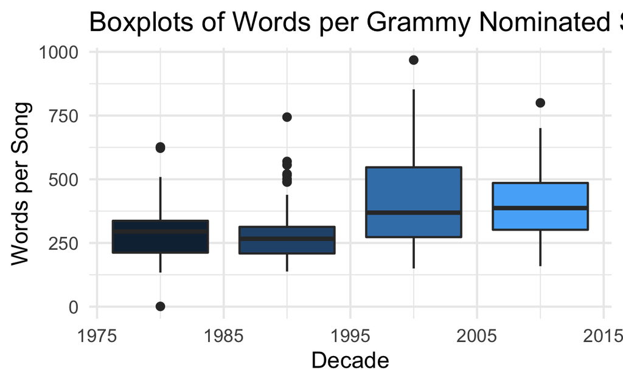

```r
ggplot(Words) +
 aes(x = decade, y = n, fill = decade, group = decade) +
 geom_boxplot() +
 labs(x = "Decade", y = "Words per Song", title = "Boxplots of Words per Grammy Nominated Song by Decade") +
 theme_minimal() +
 theme(legend.position = "none")
```